# p8105_hw1_mf3593

Miao Fu

2023-09-18

I’m an R Markdown document!

#Problem 1

```r
library(moderndive)
library(tidyverse)
```

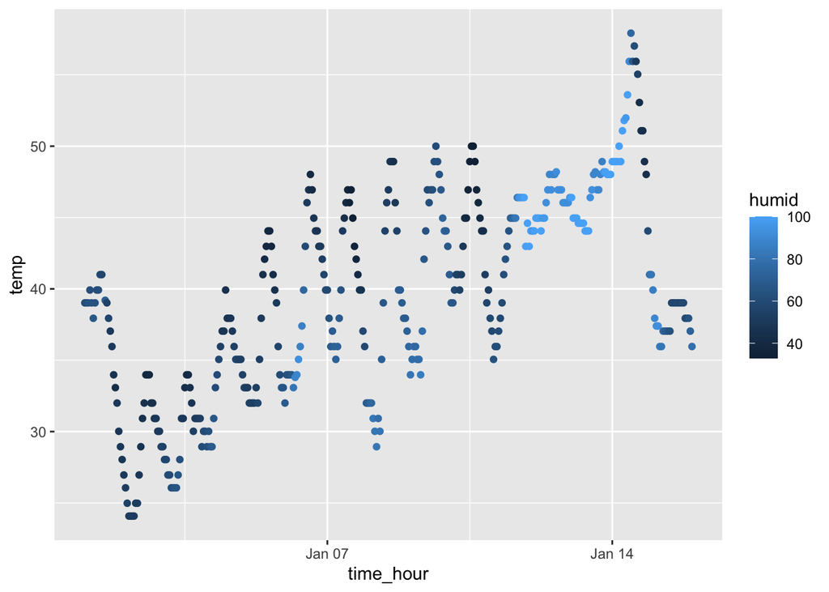

```r
data("early_january_weather")
ggplot(early_january_weather, aes(x=time_hour,y=temp,color=humid))+geom_point()
```

```r
ggsave("early_january_weather.pdf")
```

the dataset contains weather information for EWR in January of the year 2013. It has variables origin, year, month, day, hour, temp, dewp, humid, wind_dir, wind_speed, wind_gust, precip, pressure, visib, time_hour. It records temp, dewp, humid, wind_dir, wind_speed, wind_gust, precip, pressure, visib every hour on every day for fifteen days in January 2013. The size of the dataset is 358 rows 15 columns. The mean temperature is 39.5821229

According to the scatterplot of this dataset, we can see the temperature fluctuates a lot within one day but overall increased from Jan 01 to Jan 15. The humidity also in general increased over the 15 days.

#Problem 2

```r
df=tibble(
  x=rnorm(10),
  log_vec=x>0,
  cha_vec=c("A","B","C","D","E","F","G","H","I","J"),
  fac_vec=factor(c("Low","Medium","Medium","High","Low","Medium","High","High","Low","High"))
)
mean_x=mean(pull(df,x))
mean_log=mean(pull(df,log_vec))
mean_cha=mean(pull(df,cha_vec))
```

```
## Warning in mean.default(pull(df, cha_vec)): argument is not numeric or logical:
## returning NA
```

```r
mean_fac=mean(pull(df,fac_vec))
```

```
## Warning in mean.default(pull(df, fac_vec)): argument is not numeric or logical:
## returning NA
```

when calculating mean, mean function works for x and mean_log, but mean_cha and mean_fac return NA and a warning message shows argument is not numeric or logical: returning NA.